# Exercise 13.2

Manuela Giansante

2022-11-27

Set up the environment and download libraries

```r
# Download the needed libraries
library(data.table) #to read the data
library(naniar) # missing values
library(caret)  # to partition the data, lift
library(kableExtra) # to create tables
library(gains) # for lift charts
library(forecast)  # for the predict()
library(rpart) # to generate the regression trees
library(rpart.plot) # to plot the tree
library(adabag)
library(randomForest)
library(lift) # topDecileLift()
library(ggplot2)
```

```r
df <- fread("eBayAuctions.csv")
df2<- data.frame(df)
str(df2) #structure of the dataset
```

```
## 'data.frame':    1972 obs. of  8 variables:
##  $ Category    : chr  "Music/Movie/Game" "Music/Movie/Game" "Music/Movie/Game" "Music/Movie/Game" ...
##  $ currency    : chr  "US" "US" "US" "US" ...
##  $ sellerRating: int  3249 3249 3249 3249 3249 3249 3249 3249 3249 3249 ...
##  $ Duration    : int  5 5 5 5 5 5 5 5 5 5 ...
##  $ endDay      : chr  "Mon" "Mon" "Mon" "Mon" ...
##  $ ClosePrice  : num  0.01 0.01 0.01 0.01 0.01 0.01 0.01 0.01 0.01 0.01 ...
##  $ OpenPrice   : num  0.01 0.01 0.01 0.01 0.01 0.01 0.01 0.01 0.01 0.01 ...
##  $ Competitive.: int  0 0 0 0 0 0 0 0 0 0 ...
```

```r
head(df2)
```

```
##           Category currency sellerRating Duration endDay ClosePrice OpenPrice
## 1 Music/Movie/Game       US         3249        5    Mon       0.01      0.01
## 2 Music/Movie/Game       US         3249        5    Mon       0.01      0.01
## 3 Music/Movie/Game       US         3249        5    Mon       0.01      0.01
## 4 Music/Movie/Game       US         3249        5    Mon       0.01      0.01
## 5 Music/Movie/Game       US         3249        5    Mon       0.01      0.01
## 6 Music/Movie/Game       US         3249        5    Mon       0.01      0.01
##   Competitive.
## 1            0
## 2            0
## 3            0
## 4            0
## 5            0
## 6            0
```

```r
summary(df2) # main stats from the dataset
```

```
##    Category           currency          sellerRating      Duration
##  Length:1972        Length:1972        Min.   :    0   Min.   : 1.000
##  Class :character   Class :character   1st Qu.:  595   1st Qu.: 5.000
##  Mode  :character   Mode  :character   Median : 1853   Median : 7.000
##                                        Mean   : 3560   Mean   : 6.486
##                                        3rd Qu.: 3380   3rd Qu.: 7.000
##                                        Max.   :37727   Max.   :10.000
##     endDay            ClosePrice        OpenPrice       Competitive.
##  Length:1972        Min.   :  0.010   Min.   :  0.01   Min.   :0.0000
##  Class :character   1st Qu.:  4.907   1st Qu.:  1.23   1st Qu.:0.0000
##  Mode  :character   Median :  9.995   Median :  4.50   Median :1.0000
##                     Mean   : 36.449   Mean   : 12.93   Mean   :0.5406
##                     3rd Qu.: 28.000   3rd Qu.:  9.99   3rd Qu.:1.0000
##                     Max.   :999.000   Max.   :999.00   Max.   :1.0000
```

```r
sapply(df, function(x) length(unique(x))) # unique length of the variables
```

```
##     Category     currency sellerRating     Duration       endDay   ClosePrice
##           18            3          461            5            7          827
##    OpenPrice Competitive?
##          291            2
```

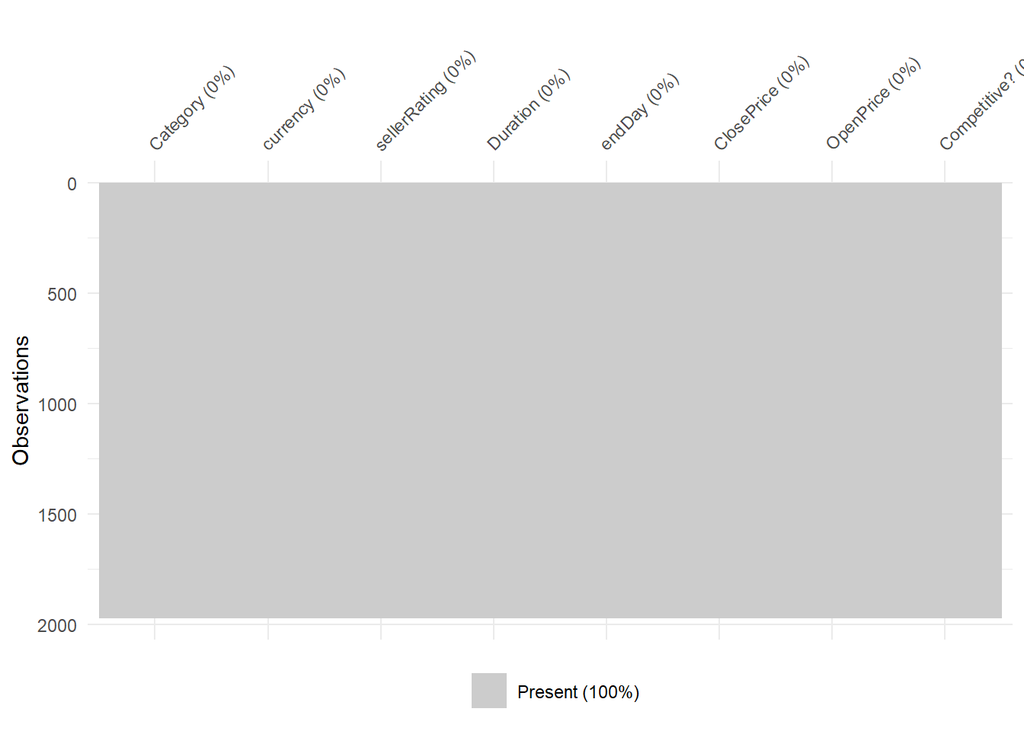

```r
vis_miss(df, warn_large_data =  FALSE)
```

```r
summary(df2$Competitive.==1)
```

```
##    Mode   FALSE    TRUE
## logical     906    1066
```

Many of the predictors are Characters. `Category` describes what the object being auctioned is. `SellerRating` takes integer values. `endDay` takes the name of the day of the day the auction concluded. `Competitive` is the outcome variable we want to classify by. Competitive. equal to 1 is the dominant class, basic classificators will tend to classify cases as belonging to this class.

```r
summary(df2$Competitive==1)
```

```
##    Mode   FALSE    TRUE
## logical     906    1066
```

```r
# set the character variables as factors
# we do this now, otherwise the functions boosting and bagging cannot work
df2[,c(1,2,5,8)] <- lapply(df2[,c(1,2,5,8)], as.factor)
```

The class that appears the most often is Competitive==1, we will set it as the positive class.

Partition the data:

```r
set.seed(1234) # to randomly select the records that will make up the samples, and get the same samples when we re-run the code
training<- sample(row.names(df2), 0.6*dim(df2)[1]) # 60% of records makeup the training set
validation <- setdiff(row.names(df2), training ) # 40% the validation set, all records not previously sorted in the training set
train.df<- df2[training,] #in data.frame format
valid.df<- df2[validation,] #in data.frame format
```

### Classification Tree

### 13.2.a

```r
options(scipen = 999)
set.seed(1234) # make it replicable
ebay_t <- rpart(Competitive. ~ ., data = train.df, method = "class")
length(ebay_t$frame$var[ebay_t$frame$var == "<leaf>"]) # how many end nodes
```

```
## [1] 12
```

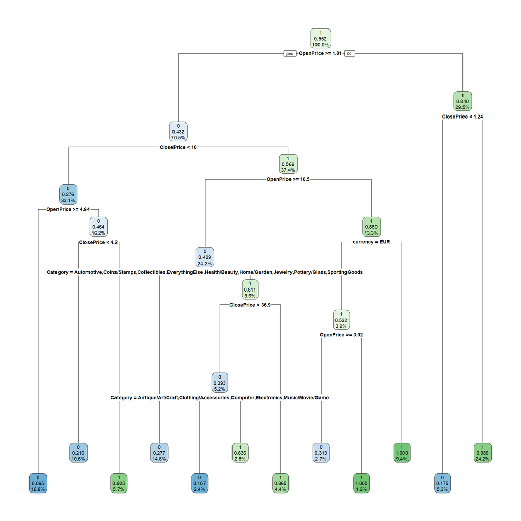

```r
rpart.plot(ebay_t, yesno = TRUE, digits =-3) # plot the tree
```

The tree has 12 end leaves.

```r
ebay_pred <- predict(ebay_t, valid.df, type="class") # predict classification
ebay_prob<- predict(ebay_t, valid.df, type = "prob") # predict probabilities of classification
ebay_cf<- confusionMatrix(ebay_pred, valid.df$Competitive., positive = "1") # build confusion matrix
ebay_cf$overall[1]# accuracy
```

```
##  Accuracy
## 0.8314322
```

```r
ebay_cf$byClass[c(1,2)] # Sensitivity and specificity
```

```
## Sensitivity Specificity
##   0.7869249   0.8803191
```

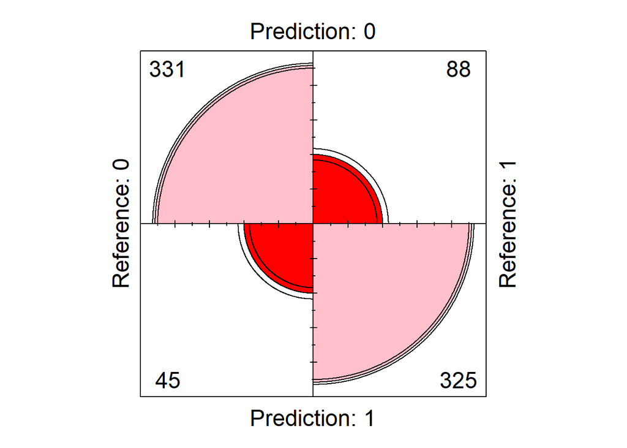

```r
fourfoldplot(ebay_cf$table, color = c("red", "pink"))
```

- The accuracy measure for the classification the tree conducts amounts to 83%

Sensitivity=A/(A+C) Specificity = D/(B+D)

- Sensitivity tells us how good is our model at detecting records belonging to the psoitive class, which in our case is 1. It amounts to 78% of correctly classified records belonging to class competitive=1.
- Specificity tells us how exact the assignment to class 1 (the positive one) is, in this case it is exact in 88% of the cases.

### Lift Chart

A lift chart helps us understand how successful our model was in classifying. It does so by ordering the observed values of the outcome variable (Competitive.) by the decreasing probabilities our model predicted (table 5.6). We then spit this ordered set into deciles, so to have a top decile, which the most “successful” in terms of how many responders or what other class is our class of interest.

In our case is the most “competitive” decile.

source: (https://select-statistics.co.uk/blog/cumulative-gains-and-lift-curves-measuring-the-performance-of-a-marketing-campaign/)

we use methods from caret package document on moodle: (http://topepo.github.io/caret/measuring-performance.html#lift-curves)

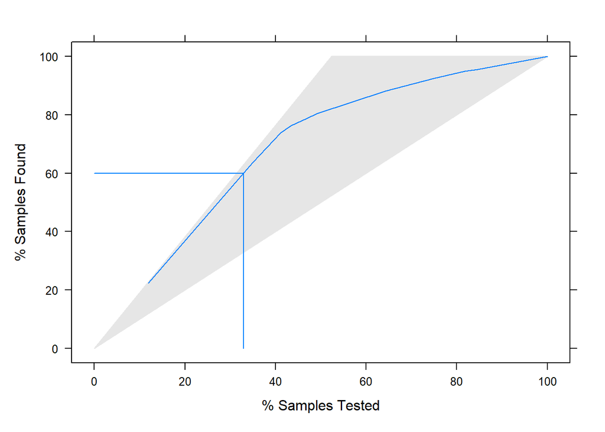

```r
#new dataset with the variables needed in the lift function, otherwise the function searches within the environment
# select the predicted probabilities for competitive.=1
lift_results<- data.frame(true_class = valid.df$Competitive., prob = ebay_prob[,2])

lift_obj <- lift(relevel(as.factor(true_class), ref="1") ~ prob, data = lift_results) #to plot our lift curve (figure 5.6)
# the lift_results are ordered by the predicted probabilities
# each value is treated as cut point
# number of samples with observed competitive.=1 are determined
# lift computed as the ratio of the % of samples in each split for y=1 over the same % in the entire set

gain_table <- gains(actual = as.numeric(as.character(lift_results$true_class)),predicted = lift_results$prob, groups=dim(lift_results)[1])
# we build the table alike table 5.6, we turn the outcome variable into numeric, so that we can compute cumulative sums
# actual response values, turned into their corresponding numeric values and predictions

dec_gain <- gains(actual = as.numeric(as.character(lift_results$true_class)), predicted= lift_results$prob, groups = 10,ties.method=c("first"))
# figure 5.7
# groups in this case at default value 10, we are computing deciles

deciles<- dec_gain$mean.resp / mean(as.numeric(as.character(lift_results$true_class)))
# mean response in decile/ "average" class in all observations

par(mfrow=c(1,2)) #organise space
plot(lift_obj, values = 60, auto.key = list(columns = 1,lines = TRUE, points = T)) # plot releveled lift curve
```

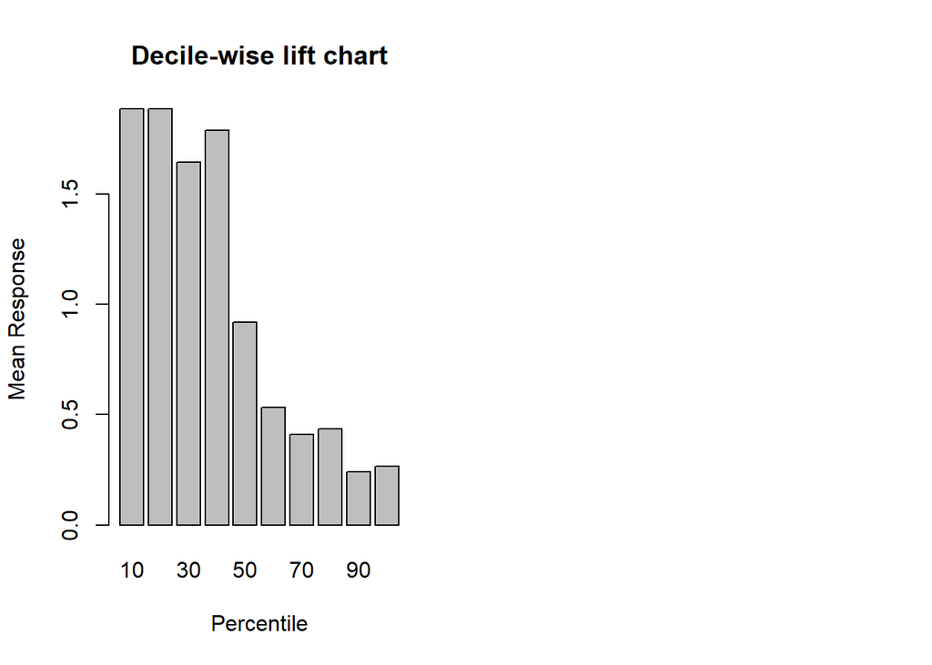

```r
barplot(deciles, names.arg = dec_gain$depth, xlab = "Percentile", ylab = "Mean Response", main = "Decile-wise lift chart") #decile chart
```

The ideal lift chart would trace the top perimeter of the grey area. The chart seems to demonstrate that our pruned tree seems to classify well enough. Which is in line with the 0.831 accuracy measure from the confusion matrix.

```r
TopDecileLift(lift_results$prob, valid.df$Competitive.) # compute the lift for the top decile
```

```
## [1] 1.862
```

The lift in the top decile amounts to 1.86. A lift of 1 would mean no improvement in classifying with the model is achieved, and that randomly selecting records would yield equivalent results.

### Boosting

### 13.2.b

Boosting fits multiple trees, so to draw samples that give higher selection probabilities to mis-classified records, and fit new trees on these new samples. This process is repeated multiple times, and the weights are updated so to give more importance to the mis-classified records.

```r
set.seed(1234) #make the process replicable
boosting <- boosting(Competitive. ~ ., data = train.df)
boost_pred<- predict(boosting, valid.df, type="class")# predict class
boost_prob<- predict(boosting, valid.df, type="prob") # predict probabilities
boost_cf <- confusionMatrix(as.factor(boost_pred$class), valid.df$Competitive., positive = "1")# table 13.1
boost_cf$overall[1] # accuracy
```

```
##  Accuracy
## 0.8846641
```

```r
boost_cf$byClass[c(1,2)] # Sensitivity and specificity
```

```
## Sensitivity Specificity
##   0.8765133   0.8936170
```

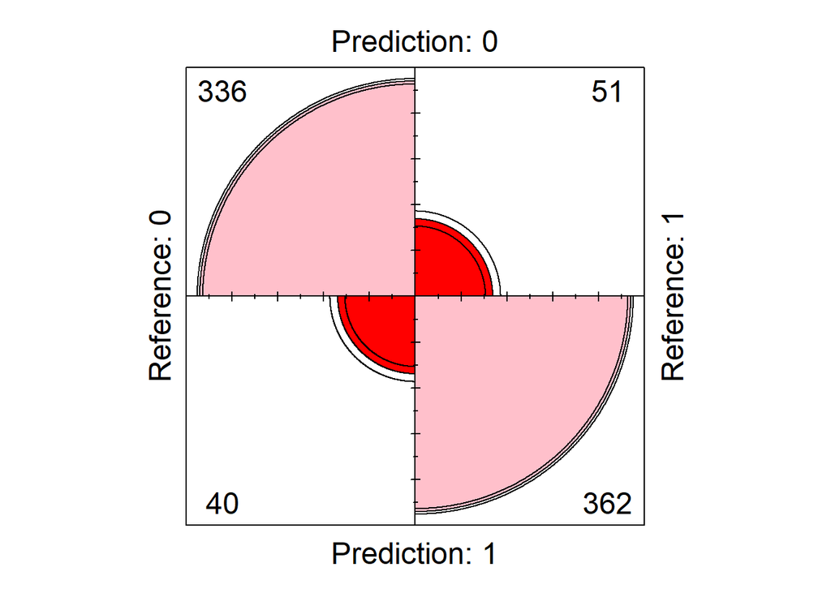

```r
fourfoldplot(boost_cf$table, color = c("red", "pink")) # plot matrix
```

Compared to the first tree, accuracy measure has increased, 88% of predictions are correct . Detection of records belonging of the first class has improved as well, Sensitivity and Specificity are respectively 87% and 89%. Boosted Tree approach produced more accurate categorization.

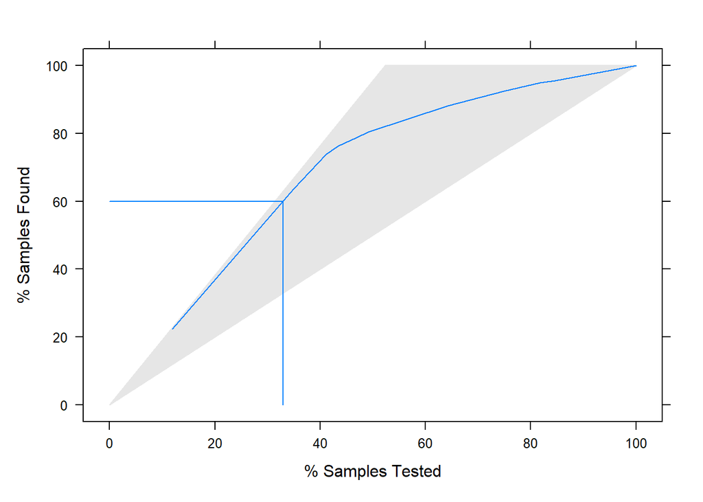

```r
# repeat process to build lift, gain chart as before
boost_results<- data.frame(true_class = valid.df$Competitive., prob = boost_prob$prob[,2])

lift_boost <- lift(relevel(as.factor(true_class), ref="1") ~ prob, data = lift_results)

gain_table_boost <- gains(actual = as.numeric(as.character(boost_results$true_class)),predicted = boost_results$prob, groups=dim(boost_results)[1])
dec_gain_boost <- gains(actual = as.numeric(as.character(boost_results$true_class)), predicted= boost_results$prob, groups = 10,ties.method=c("first"))

deciles_boost<- dec_gain_boost$mean.resp / mean(as.numeric(as.character(boost_results$true_class)))

par(mfrow=c(1,2)) #organise space
plot(lift_boost, values = 60, auto.key = list(columns = 1,lines = TRUE, points = T))
```

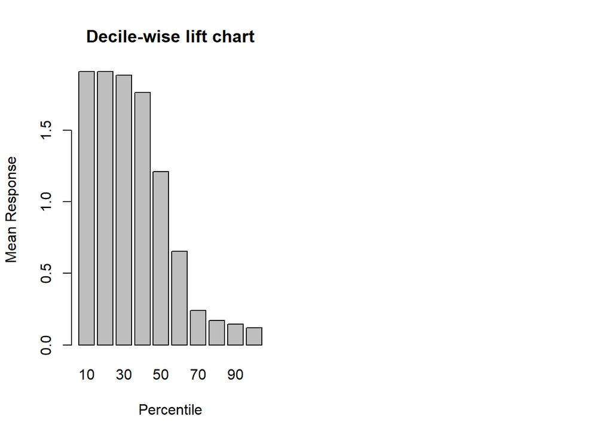

```r
barplot(deciles_boost, names.arg = dec_gain_boost$depth, xlab = "Percentile", ylab = "Mean Response", main = "Decile-wise lift chart")
```

```r
TopDecileLift(boost_results$prob, valid.df$Competitive.) # compute the lift for the top decile
```

```
## [1] 1.91
```

### Bagging

### 13.1.c

The process generates multiple random samples (with replacement), then runs an algorithm over these samples and produces scores.

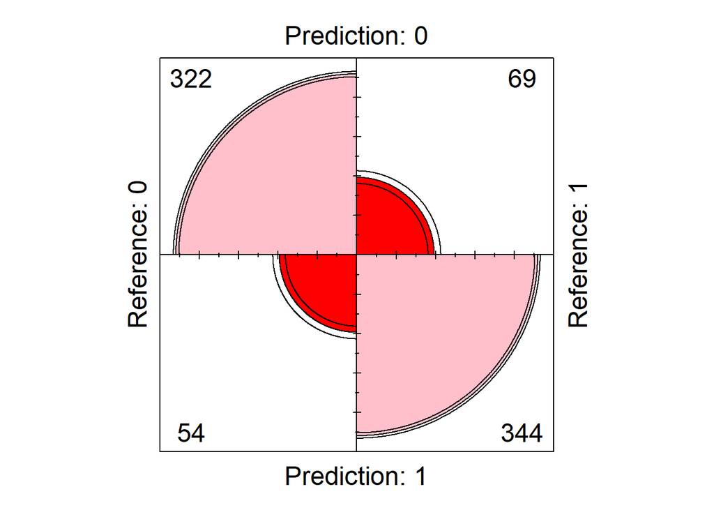

```r
set.seed(1234)
bagging<- bagging(Competitive. ~ ., data = train.df)
bag_pred<- predict(bagging, valid.df, type="class") # classes
bag_prob<- predict(bagging, valid.df, type="prob")  # probabilities
bag_cf <- confusionMatrix(as.factor(bag_pred$class), valid.df$Competitive., positive = "1")

fourfoldplot(bag_cf$table, color = c("red", "pink")) #plot confusion matrix
```

```r
bag_cf$overall[1] # Accuracy
```

```
##  Accuracy
## 0.8441065
```

```r
bag_cf$byClass[c(1,2)] # Sensitivity and specificity
```

```
## Sensitivity Specificity
##   0.8329298   0.8563830
```

Accuracy measure is higher than original model, but not as high as the boosted tree, the value is 84%. The byClass statistics describe a less successful model as well.

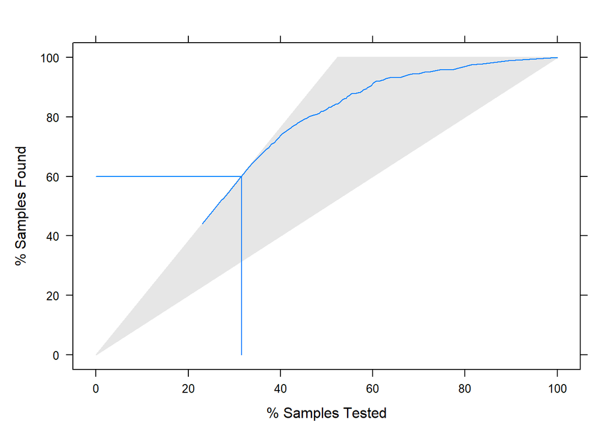

```r
#Repeat process for lift chart
bag_results<- data.frame(true_class = valid.df$Competitive., prob = bag_prob$prob[,2])

lift_bag <- lift(relevel(as.factor(true_class), ref="1") ~ prob, data = bag_results) #to plot our lift curve


gain_table_bag <- gains(actual = as.numeric(as.character(bag_results$true_class)),predicted = bag_results$prob, groups=dim(bag_results)[1])

dec_gain_bag<- gains(actual = as.numeric(as.character(bag_results$true_class)), predicted= bag_results$prob, groups = 10,ties.method=c("first"))

deciles_bag<- dec_gain_bag$mean.resp / mean(as.numeric(as.character(bag_results$true_class)))

par(mfrow=c(1,2)) #organise space
plot(lift_bag, values = 60, auto.key = list(columns = 1,lines = TRUE, points = T))
```

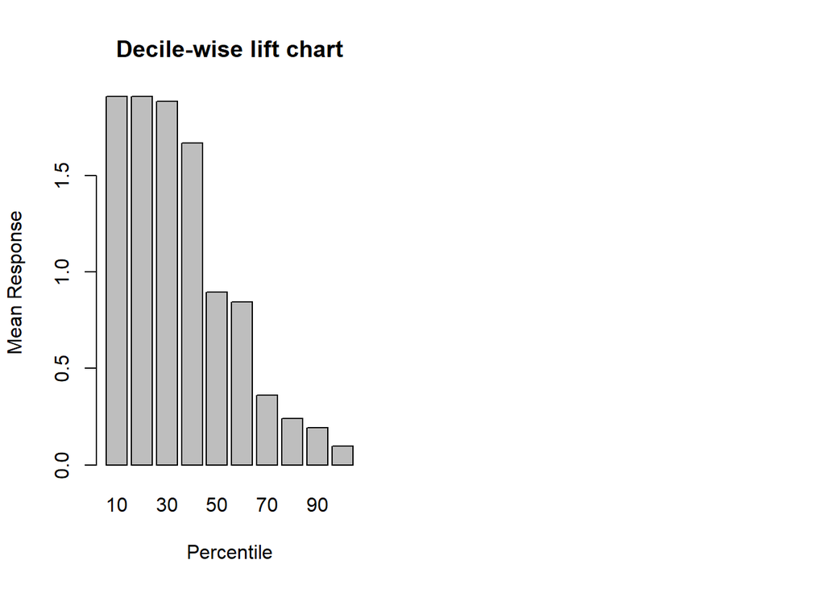

```r
barplot(deciles_bag, names.arg = dec_gain_bag$depth, xlab = "Percentile", ylab = "Mean Response", main = "Decile-wise lift chart")
```

```r
TopDecileLift(bag_results$prob, valid.df$Competitive.) # compute the lift for the top decile
```

```
## [1] 1.91
```

Accuracy wise Boosted seems to perform slightly better. Overall, both models display improved classification performance. The lift given by the 2 improved models seems to be the same between thought. This tells us that the mis-classification for the bagging process happens for higher deciles of the “population”.

### Random Forest

### 13.2.d

Random Forest uses bootstrap sampling as well. In this case the sample over which we fit trees over, are random. It then combines the predictions to obtain a improved classification performance.

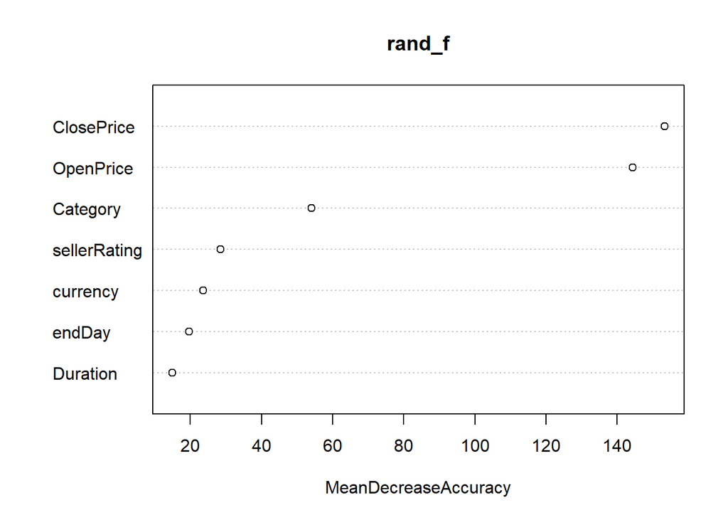

```r
set.seed(1234)
rand_f <- randomForest(Competitive. ~ ., data = train.df, mtry=4, importance = T)
varImpPlot(rand_f, type=1) # we print out the variable importance plot too
```

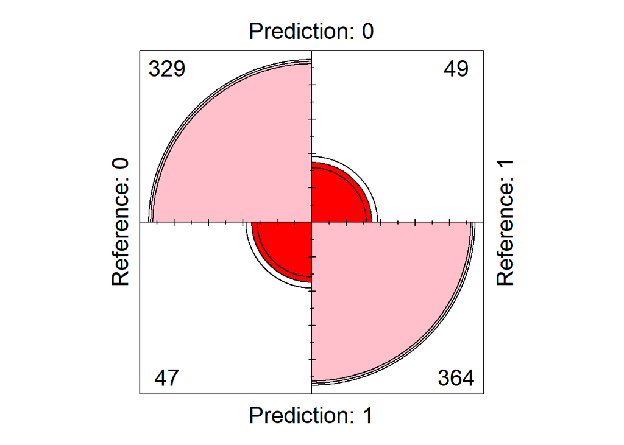

```r
rand_pred<- predict(rand_f, valid.df, type="class") # predict class
rand_prob<- predict(rand_f, valid.df, type="prob")  # predict prob
rand_cf <- confusionMatrix(as.factor(rand_pred), valid.df$Competitive., positive = "1")

fourfoldplot(rand_cf$table, color = c("red", "pink")) # plot confusion matrix
```

```r
rand_cf$overall[1] # Accuracy
```

```
## Accuracy
## 0.878327
```

```r
rand_cf$byClass[c(1,2)] # Sensitivity and specificity
```

```
## Sensitivity Specificity
##   0.8813559   0.8750000
```

Random Forests permits us to also print a plot of importance of predictors. `Close Price` and `Open Price` are the most important features in the classification process Random Forests runs.

In terms of accuracy Random forests is almost as well performing as the boosted process,it does a better job at detecting positive class records. Specificity is lower instead.

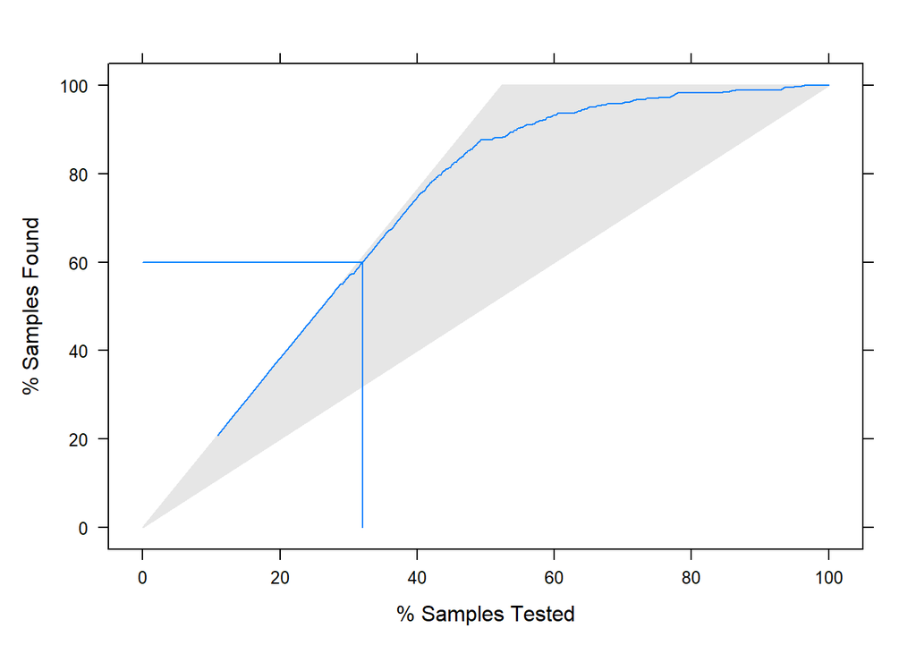

```r
#Repeat process for lift chart
rand_results<- data.frame(true_class = valid.df$Competitive., prob = rand_prob[,2])

lift_rand <- lift(relevel(as.factor(true_class), ref="1") ~ prob, data = rand_results) #to plot our lift curve


gain_table_rand <- gains(actual = as.numeric(as.character(rand_results$true_class)),predicted = rand_results$prob, groups=dim(rand_results)[1])
dec_gain_rand<- gains(actual = as.numeric(as.character(rand_results$true_class)), predicted= rand_results$prob, groups = 10,ties.method=c("first"))

deciles_rand<- dec_gain_rand$mean.resp / mean(as.numeric(as.character(rand_results$true_class)))

par(mfrow=c(1,2)) #organise space
plot(lift_rand, values = 60, auto.key = list(columns = 1,lines = TRUE, points = T))
```

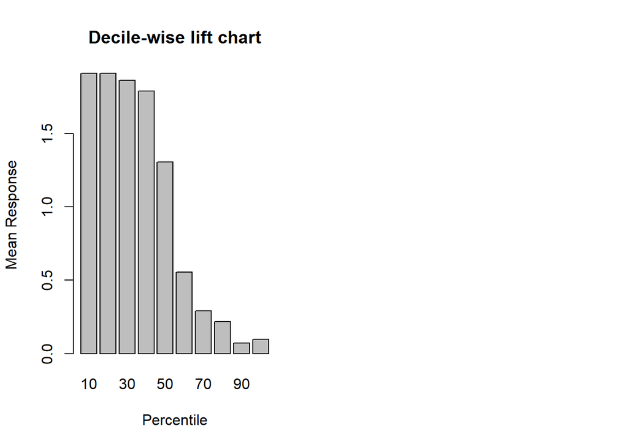

```r
barplot(deciles_rand, names.arg = dec_gain_rand$depth, xlab = "Percentile", ylab = "Mean Response", main = "Decile-wise lift chart")
```

```r
options(digits = 3)
TopDecileLift(rand_results$prob, valid.df$Competitive.) # compute the lift for the top decile
```

```
## [1] 1.91
```

For all 3 processes the lift in the first decile is the same, again this tells us that the first decile is classified equally well by the models, but given the differences in accuracy measures, most likely issues incur with later deciles.

### Bagged Tree vs Random Forest

### 13.2.d

Random Forests can be described as an ensemble of bagged trees.The main difference is that in fitting classification Random Forests uses a random subset of predictors. In bagging the predictors are always the same! Voting is used for classification in both methods, same goes for averaging for prediction.

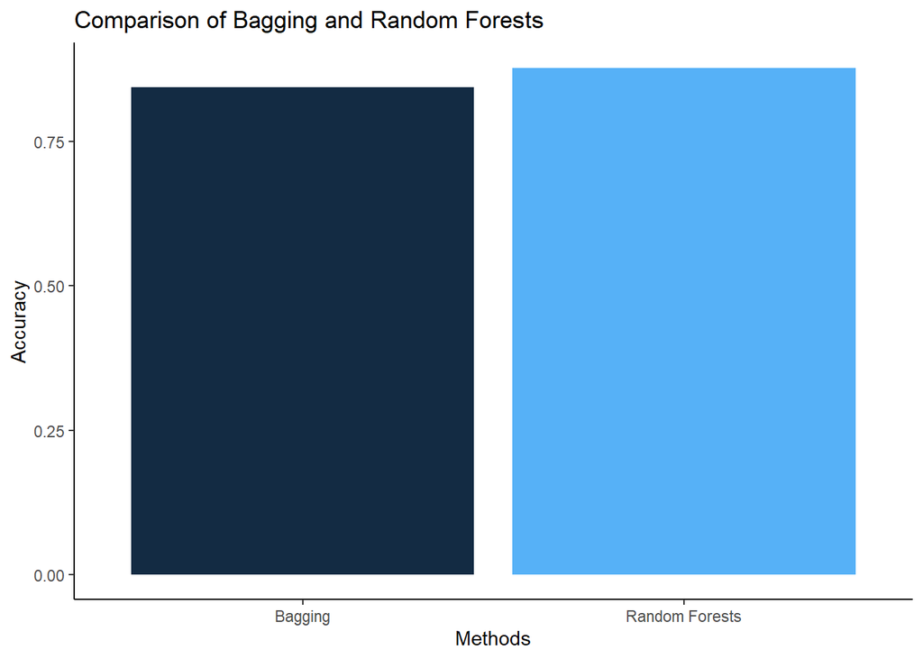

```r
accuracies<- data.frame("Methods"= c("Bagging", "Random Forests"), "Accuracy"= c(bag_cf$overall[1], rand_cf$overall[1])) #accuracies
ggplot(accuracies) + geom_col(aes(x=Methods,y= Accuracy, fill=Accuracy), show.legend = F)+ theme_classic()+ ggtitle("Comparison of Bagging and Random Forests") #comparison
```

Random Forests seems to perform better in terms of Accuracy, and Specificity and Sensitivity. In this sense the “ensemble” of bagged trees improves the quality of our predictions.